# Statistical Analysis of Global Terrorism Patterns

```r
#Libraries
library(tidyverse)
```

```r
library(ggcorrplot)
library(caret)
library(glmnet)
library(ISLR2)
library(leaps)
library(MASS)
library(dplyr)
library(ggplot2)
library(randomForest)
library(xgboost)
library(e1071)
```

# Summary

This project uses the GTD Global Terrorism Database, which contains data on terrorist attacks worldwide from 1970 to 2020. The original dataset includes 209,706 observations and 135 variables. For this analysis, the dataset was reduced to 45 variables by selecting those that showed at least a ±0.05 correlation with either latitude or longitude. This filtering step was used to focus on variables that have geographic relevance, since location is a central component of the analysis.

The project applies both supervised and unsupervised learning methods to better understand patterns in the data. Supervised models are used to predict whether an attack is successful, while unsupervised clustering is used to examine how attacks group geographically. Special attention is given to handling missing data and class imbalance, which are two major challenges in this dataset. Overall, the goal is to build models that not only perform well, but also provide meaningful insight into how terrorist activity is distributed and influenced by different factors.

# Purpose

The purpose of this project is to better understand patterns in global terrorist activity and evaluate how well different machine learning models can predict attack outcomes. Specifically, the analysis focuses on whether an attack is successful and how geographic location influences patterns in the data.

| The main questions being addressed are: |
| --- |
| - Can terrorist attack success be predicted using available features in the dataset? |
| - How does class imbalance affect model performance? |
| - Which machine learning models perform best for this type of data? |
| - Are there clear geographic patterns in where attacks occur? |

This analysis is important because understanding patterns in terrorist activity can help identify trends that may not be immediately obvious. The results could be useful for researchers, analysts, or policymakers who are interested in risk patterns, geographic clustering, or predictive modeling in security-related data. Additionally, the project highlights practical challenges in real-world data, such as missing values and imbalanced classes, and demonstrates how different modeling approaches handle those issues.

# Data

The dataset used in this project is the Global Terrorism Database (GTD), which contains detailed information on terrorist events from 1970 to 2020. The original dataset includes 209,706 observations and 135 variables covering geographic, operational, and contextual details of each attack.

To make the dataset more manageable and relevant to the analysis, it was filtered down to 45 variables. Variables were selected based on having at least a ±0.05 correlation with either latitude or longitude, ensuring that the remaining features had some geographic significance. The final dataset maintains all 209,706 observations while focusing on the most relevant variables.

Only numeric variables were used in the analysis. Character variables were removed because they were not necessary, and most had corresponding numeric-coded versions that preserved the same information. Additionally, the dataset uses -99 as a placeholder for missing values, so these were converted to NA for proper handling during analysis.

Missing data is a significant characteristic of this dataset, with many observations containing at least one missing value. Instead of removing all incomplete rows, missing values were handled separately for each model to preserve as much data as possible. This approach allowed for more flexibility and better use of the available information.

A data dictionary was also created to describe each variable, including its name, meaning, type, and example values. This ensures clarity and helps support the interpretation of the results throughout the analysis. ### Data Dictionary

```r
# Data Dictionary
data_dictionary <- data.frame(
  Variable = c(
    "eventid","iyear","country","region","latitude","longitude","doubtterr","success",
    "suicide","attacktype2","attacktype3","targtype2","targsubtype2","natlty2","natlty3",
    "guncertain1","guncertain2","nperps","claim2","claimmode2","claim3","claimmode3",
    "weapsubtype1","weapsubtype2","weaptype3","weapsubtype3","weaptype4","weapsubtype4",
    "property","nhours","ransomamt","ransomamtus","INT_LOG","INT_IDEO","INT_MISC",
    "specificity","guncertain3","individual","nperpcap","claimmode","propextent",
    "ransom","ransompaidus","hostkidoutcome","INT_ANY"
  ),
  Description = c(
    "Unique event ID",
    "Year of event",
    "Country code",
    "Region code",
    "Latitude of event",
    "Longitude of event",
    "Doubt terrorism flag",
    "Attack success flag",
    "Suicide attack flag",
    "Secondary attack type",
    "Tertiary attack type",
    "Secondary target type",
    "Secondary target subtype",
    "Second nationality",
    "Third nationality",
    "Uncertain group 1",
    "Uncertain group 2",
    "Number of perpetrators",
    "Second claim of responsibility",
    "Second claim mode",
    "Third claim",
    "Third claim mode",
    "Weapon subtype 1",
    "Weapon subtype 2",
    "Weapon type 3",
    "Weapon subtype 3",
    "Weapon type 4",
    "Weapon subtype 4",
    "Property damage",
    "Duration in hours",
    "Ransom amount",
    "Ransom amount USD",
    "International logistics",
    "International ideology",
    "International misc",
    "Location specificity",
    "Uncertain group 3",
    "Individual attack",
    "Perpetrators captured",
    "Claim mode",
    "Property extent",
    "Ransom flag",
    "Ransom paid USD",
    "Hostage outcome",
    "Any international involvement"
  ),
  Type = c(
    "numeric","numeric","categorical","categorical","numeric","numeric","categorical","categorical",
    "categorical","categorical","categorical","categorical","categorical","categorical","categorical",
    "categorical","categorical","numeric","categorical","categorical","categorical","categorical",
    "categorical","categorical","categorical","categorical","categorical","categorical",
    "categorical","numeric","numeric","numeric","categorical","categorical","categorical",
    "numeric","categorical","categorical","numeric","categorical","categorical",
    "categorical","numeric","categorical","categorical"
  ),
  Example = c(
    "197001000001","2015","217","10","34.5","-118.2","0","1",
    "0","3","0","2","22","217","217",
    "0","1","4","1","2","0","1",
    "12","23","6","31","7","42",
    "1","5","100000","100000","0","1","0",
    "1","0","1","2","3","2",
    "1","50000","3","1"
  ),
  stringsAsFactors = FALSE
)
data_dictionary
```

```
##          Variable                    Description        Type      Example
## 1         eventid                Unique event ID     numeric 197001000001
## 2           iyear                  Year of event     numeric         2015
## 3         country                   Country code categorical          217
## 4          region                    Region code categorical           10
## 5        latitude              Latitude of event     numeric         34.5
## 6       longitude             Longitude of event     numeric       -118.2
## 7       doubtterr           Doubt terrorism flag categorical            0
## 8         success            Attack success flag categorical            1
## 9         suicide            Suicide attack flag categorical            0
## 10    attacktype2          Secondary attack type categorical            3
## 11    attacktype3           Tertiary attack type categorical            0
## 12      targtype2          Secondary target type categorical            2
## 13   targsubtype2       Secondary target subtype categorical           22
## 14        natlty2             Second nationality categorical          217
```

[output cut: 31 more lines]

# Exploration

## Raw Data

```r
RawGlobalTerrorism <- read.csv('/Users/katelynmccullough/Library/CloudStorage/OneDrive-FloridaPolytechnicUniversity/Florida Polytechnic University/Classes/Statistical Learning/GlobalTerrorismProjectData.csv')
```

```r
head(RawGlobalTerrorism, 5)
```

```
##       eventid iyear imonth iday approxdate extended resolution country
## 1 1.97000e+11  1970      7    2                   0                 58
## 2 1.97000e+11  1970      0    0                   0                130
## 3 1.97001e+11  1970      1    0                   0                160
## 4 1.97001e+11  1970      1    0                   0                 78
## 5 1.97001e+11  1970      1    0                   0                101
##          country_txt region                  region_txt provstate          city
## 1 Dominican Republic      2 Central America & Caribbean  National Santo Domingo
## 2             Mexico      1               North America   Federal   Mexico city
## 3        Philippines      5              Southeast Asia    Tarlac       Unknown
## 4             Greece      8              Western Europe    Attica        Athens
## 5              Japan      4                   East Asia   Fukouka       Fukouka
##   latitude longitude specificity vicinity location summary crit1 crit2 crit3
## 1 18.45679 -69.95116           1        0                      1     1     1
## 2 19.37189 -99.08662           1        0                      1     1     1
```

[output cut: 123 more lines]

## Data Cleaning

```r
numeric_data <- RawGlobalTerrorism[, sapply(RawGlobalTerrorism, is.numeric)]
```

```r
# Correlation with Latitude
cor_lat <- cor(numeric_data, use = "pairwise.complete.obs")[, "latitude"]
cor_lat_filtered <- cor_lat[abs(cor_lat) > 0.05]
sort(cor_lat_filtered, decreasing = TRUE)
```

```
##     latitude    longitude       region       claim3        iyear      eventid
##   1.00000000   0.25187040   0.24727406   0.19133113   0.13765608   0.13762379
##      country weapsubtype1       claim2     INT_MISC      suicide    doubtterr
##   0.13745349   0.13188644   0.11005162   0.09500808   0.06655443   0.06281788
##   claimmode3    ransomamt  ransomamtus    targtype2 targsubtype2       nperps
##   0.06184840   0.06180389   0.05577954   0.05177388   0.05055391  -0.06264329
##  guncertain1      success     property     INT_IDEO   claimmode2      INT_LOG
##  -0.06289990  -0.06726193  -0.07754180  -0.08437616  -0.08983673  -0.08992301
##       nhours weapsubtype2  guncertain2    weaptype3 weapsubtype4    weaptype4
##  -0.09828146  -0.10569225  -0.11075522  -0.14385366  -0.16109230  -0.17817794
##      natlty3      natlty2  attacktype2 weapsubtype3  attacktype3
##  -0.19398197  -0.21928492  -0.22211095  -0.23568059  -0.32661607
```

```r
lat_vars <- names(cor_lat[abs(cor_lat) > 0.05])
```

```r
# Correlation with Longitude
cor_long <- cor(numeric_data, use = "pairwise.complete.obs")[, "longitude"]
cor_long_filtered <- cor_long[abs(cor_long) > 0.05]
sort(cor_long_filtered, decreasing = TRUE)
```

```
##      longitude        eventid          iyear         region       latitude
##     1.00000000     0.52862200     0.52862127     0.36194215     0.25187040
##   weapsubtype4       nperpcap      doubtterr    specificity      weaptype4
##     0.21209518     0.19814497     0.12939857     0.11115770     0.09534623
##    guncertain3 hostkidoutcome      claimmode        suicide    guncertain2
##     0.08798816     0.08689925     0.06287495     0.05738508     0.05360148
##     claimmode2        natlty2        success     propextent     individual
##     0.05341809    -0.05329374    -0.05516803    -0.07084461    -0.07590261
##   ransompaidus       INT_IDEO        INT_LOG         ransom        INT_ANY
##    -0.09914703    -0.10062098    -0.10501643    -0.11527826    -0.11763586
##    attacktype3    attacktype2         claim3       property     claimmode3
##    -0.12535952    -0.14005649    -0.15950403    -0.16300388    -0.27257650
##         nhours
##    -0.30993995
```

```r
long_vars <- names(cor_long[abs(cor_long) > 0.05])
long_vars
```

```
##  [1] "eventid"        "iyear"          "region"         "latitude"
##  [5] "longitude"      "specificity"    "doubtterr"      "success"
##  [9] "suicide"        "attacktype2"    "attacktype3"    "natlty2"
## [13] "guncertain2"    "guncertain3"    "individual"     "nperpcap"
## [17] "claimmode"      "claimmode2"     "claim3"         "claimmode3"
## [21] "weaptype4"      "weapsubtype4"   "property"       "propextent"
## [25] "nhours"         "ransom"         "ransompaidus"   "hostkidoutcome"
## [29] "INT_LOG"        "INT_IDEO"       "INT_ANY"
```

```r
vars_to_use <- union(lat_vars, long_vars)
vars_to_use
```

```
##  [1] "eventid"        "iyear"          "country"        "region"
##  [5] "latitude"       "longitude"      "doubtterr"      "success"
##  [9] "suicide"        "attacktype2"    "attacktype3"    "targtype2"
## [13] "targsubtype2"   "natlty2"        "natlty3"        "guncertain1"
## [17] "guncertain2"    "nperps"         "claim2"         "claimmode2"
## [21] "claim3"         "claimmode3"     "weapsubtype1"   "weapsubtype2"
## [25] "weaptype3"      "weapsubtype3"   "weaptype4"      "weapsubtype4"
## [29] "property"       "nhours"         "ransomamt"      "ransomamtus"
## [33] "INT_LOG"        "INT_IDEO"       "INT_MISC"       "specificity"
## [37] "guncertain3"    "individual"     "nperpcap"       "claimmode"
## [41] "propextent"     "ransom"         "ransompaidus"   "hostkidoutcome"
## [45] "INT_ANY"
```

```r
vars_to_use <- union(vars_to_use, c("latitude", "longitude"))
```

This step identifies all variables that are significantly correlated with either latitude or longitude, with duplicate variables removed. This results in a final set of 45 variables considered significant for the analysis.

```r
filteredGlobalTerrorism <- RawGlobalTerrorism[, vars_to_use]
```

This step creates a filtered dataset by selecting only the variables identified as significant, resulting in a refined dataset that includes the most relevant features for analysis.

```r
cor_lat <- cor(filteredGlobalTerrorism, use = "pairwise.complete.obs")[, "latitude"]
top_vars <- names(sort(abs(cor_lat), decreasing = TRUE)[1:10])
filteredcor_small <- cor(filteredGlobalTerrorism[, top_vars],
                         use = "pairwise.complete.obs")
```

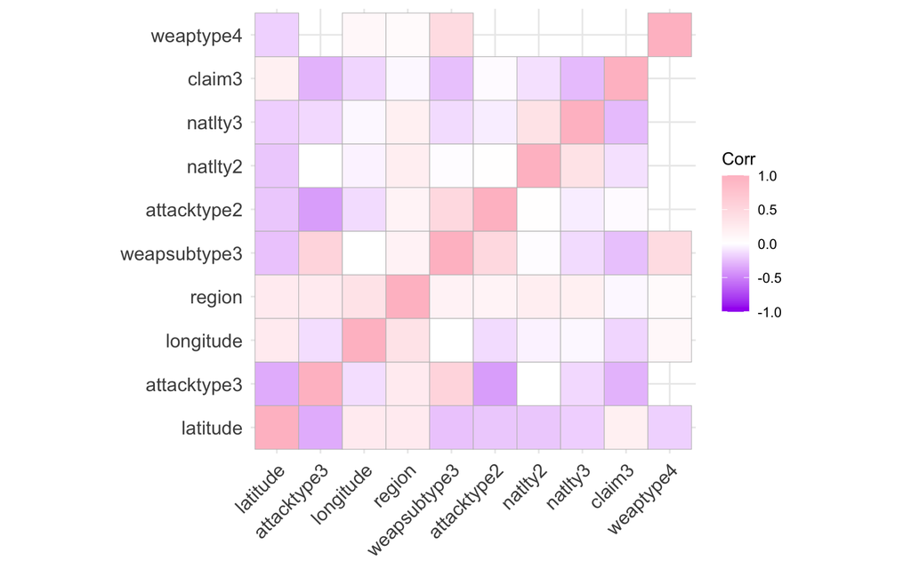

```r
ggcorrplot(filteredcor_small,
           colors = c("purple", "white", "pink"),
           lab = FALSE)
```

```r
cor_success <- cor(filteredGlobalTerrorism, use = "pairwise.complete.obs")[, "success"]
top_vars <- names(sort(abs(cor_lat), decreasing = TRUE)[1:10])
filteredcor_small <- cor(filteredGlobalTerrorism[, top_vars],
                         use = "pairwise.complete.obs")
```

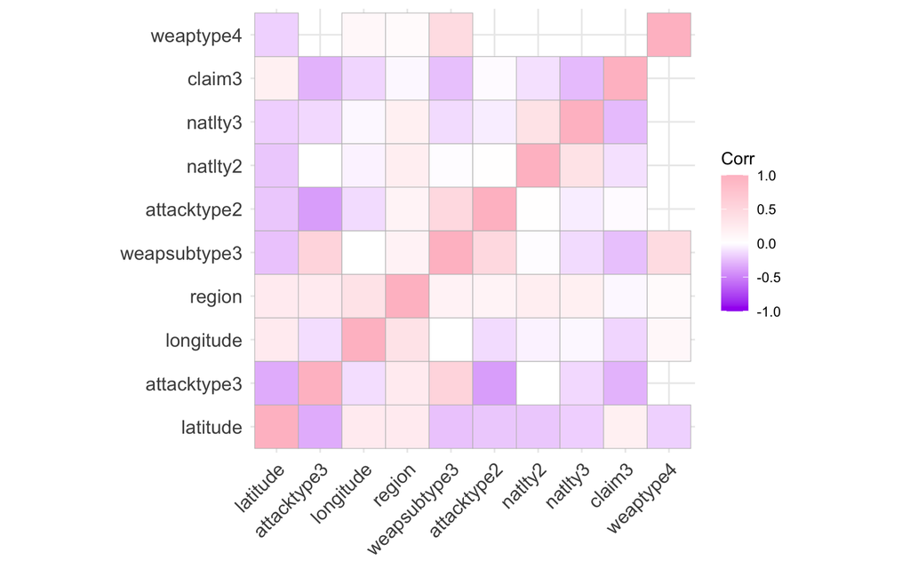

```r
ggcorrplot(filteredcor_small,
           colors = c("purple", "white", "pink"),
           lab = FALSE)
```

## Filtered Data

```r
head(filteredGlobalTerrorism)
```

```
##       eventid iyear country region latitude longitude doubtterr success suicide
## 1 1.97000e+11  1970      58      2 18.45679 -69.95116         0       1       0
## 2 1.97000e+11  1970     130      1 19.37189 -99.08662         0       1       0
## 3 1.97001e+11  1970     160      5 15.47860 120.59974         0       1       0
## 4 1.97001e+11  1970      78      8 37.99749  23.76273         0       1       0
## 5 1.97001e+11  1970     101      4 33.58041 130.39636        -9       1       0
## 6 1.97001e+11  1970     217      1 37.00511 -89.17627         0       1       0
##   attacktype2 attacktype3 targtype2 targsubtype2 natlty2 natlty3 guncertain1
## 1          NA          NA        NA           NA      NA      NA           0
## 2          NA          NA        NA           NA      NA      NA           0
## 3          NA          NA        NA           NA      NA      NA           0
## 4          NA          NA        NA           NA      NA      NA           0
## 5          NA          NA        NA           NA      NA      NA           0
## 6          NA          NA        NA           NA      NA      NA           0
##   guncertain2 nperps claim2 claimmode2 claim3 claimmode3 weapsubtype1
```

[output cut: 34 more lines]

This represents the final filtered dataset that will be used for the analysis.

## Dimensions

```r
dim(filteredGlobalTerrorism)
```

```
## [1] 209706     45
```

## Summary Statistics

### Histogram of latitude

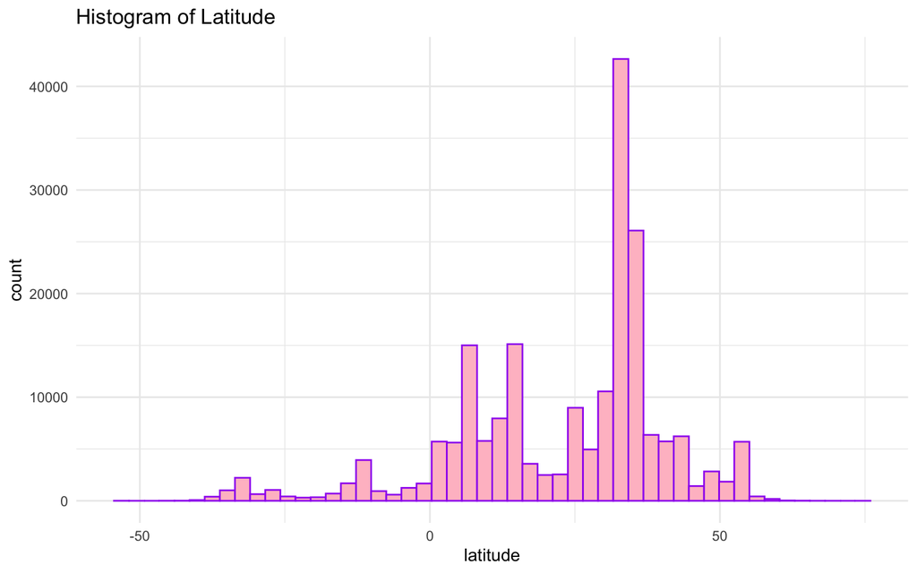

```r
ggplot(filteredGlobalTerrorism, aes(x = latitude)) +
  geom_histogram(bins = 50, fill = "pink", color = "purple") +
  theme_minimal() +
  ggtitle("Histogram of Latitude")
```

### Histogram of Longitude

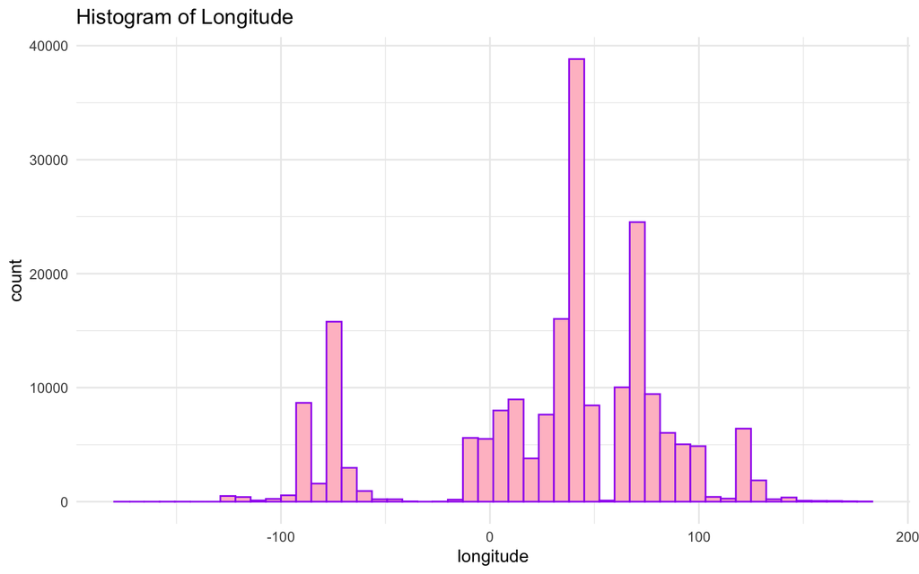

```r
ggplot(filteredGlobalTerrorism, aes(x = longitude)) +
  geom_histogram(bins = 50, fill = "pink", color = "purple") +
  theme_minimal() +
  ggtitle("Histogram of Longitude")
```

### Scatterplot of Latitude and Longitude, by region

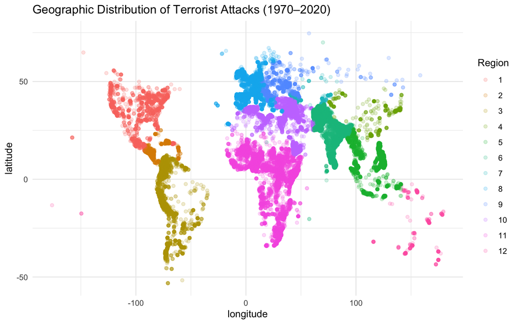

```r
ggplot(filteredGlobalTerrorism,
       aes(x = longitude, y = latitude, color = factor(region))) +
  geom_point(alpha = 0.2) +
  theme_minimal() +
  ggtitle("Geographic Distribution of Terrorist Attacks (1970–2020)") +
  labs(color = "Region")
```

This scatter plot shows the geographic distribution of terrorist attacks using longitude and latitude, with points colored by region. The visualization reveals clear geographic clustering, where points naturally form shapes that resemble real-world continents and regions. Areas with darker concentrations of points indicate regions with higher frequencies of attacks, while lighter areas represent lower activity. Overall, the plot highlights that terrorist activity is not randomly distributed, but instead concentrated in specific geographic regions, reinforcing the importance of location in the analysis.

### Number of attacks by region

```r
table(filteredGlobalTerrorism$region)
```

```
##
##     1     2     3     4     5     6     7     8     9    10    11    12
##  3847 10386 19846   847 14498 54725   580 17328  5326 58252 23746   325
```

This table displays the number of terrorist attacks by region. Region 10, which includes parts of North Africa, the Middle East, and Southern Europe, has the highest number of recorded attacks. It is followed by Region 6, which also shows a high concentration of activity. In contrast, Regions 4, 7, and 12 have significantly fewer recorded attacks, indicating relatively low levels of activity in those areas. Overall, the distribution of attacks varies greatly by region, with a few regions accounting for the majority of events.

### Summary for Data

```r
summary(filteredGlobalTerrorism[, c(
  "latitude",
  "longitude",
  "iyear",
  "nperps",
  "ransomamt",
  "success"
)])
```

```
##     latitude        longitude            iyear          nperps
##  Min.   :-53.15   Min.   :-176.176   Min.   :1970   Min.   :  -99.00
##  1st Qu.: 11.51   1st Qu.:   8.748   1st Qu.:1992   1st Qu.:  -99.00
##  Median : 31.30   Median :  43.746   Median :2012   Median :  -99.00
##  Mean   : 23.36   Mean   :  30.417   Mean   :2005   Mean   :  -68.82
##  3rd Qu.: 34.56   3rd Qu.:  68.836   3rd Qu.:2015   3rd Qu.:  -99.00
##  Max.   : 74.63   Max.   : 179.367   Max.   :2020   Max.   :25000.00
##  NA's   :4691     NA's   :4692                      NA's   :71093
##    ransomamt             success
##  Min.   :       -99   Min.   :0.0000
##  1st Qu.:         0   1st Qu.:1.0000
##  Median :     10000   Median :1.0000
##  Mean   :   2791526   Mean   :0.8836
##  3rd Qu.:    342000   3rd Qu.:1.0000
##  Max.   :1000000000   Max.   :1.0000
##  NA's   :208173
```

This table presents summary statistics for key variables in the dataset. Latitude and longitude values fall within expected geographic ranges, with most observations concentrated in the Northern and Eastern Hemispheres. The year variable spans from 1970 to 2020, with a higher concentration of observations in more recent years, likely reflecting improvements in reporting over time. The number of perpetrators variable contains many placeholder values of -99, indicating missing or unknown data, which heavily skews the mean and limits its interpret ability. Similarly, the ransom amount variable has a large number of missing values, with only a small portion of observations containing actual ransom data. Among those, values vary widely, ranging from relatively small amounts to extremely large outliers, resulting in a highly skewed distribution. The success variable shows that the majority of attacks are classified as successful, indicating a strong class imbalance in the dataset.

### Bar Plot of Attack Success

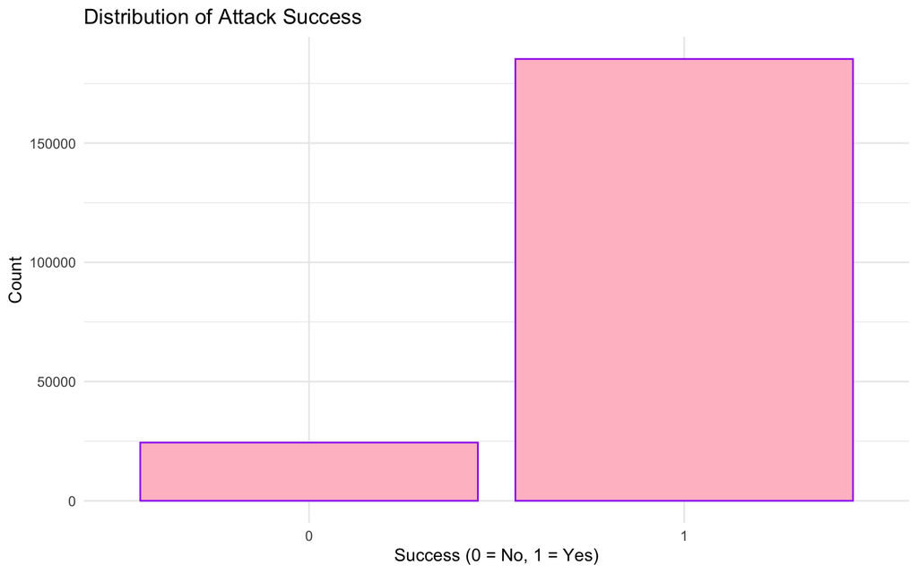

```r
ggplot(filteredGlobalTerrorism, aes(x = factor(success))) +
  geom_bar(fill = "pink", color = "purple") +
  theme_minimal() +
  ggtitle("Distribution of Attack Success") +
  xlab("Success (0 = No, 1 = Yes)") +
  ylab("Count")
```

This bar chart shows the distribution of the success variable. The majority of terrorist attacks are classified as successful, with significantly more observations in the “1” category compared to “0.” This confirms that the dataset is highly imbalanced, which is important because it can impact model performance and lead to biased predictions toward the majority class.

Overall, the dataset is relatively clean, but it does contain a substantial number of missing values across several variables. In addition, all data from 1993 is missing due to a reported data loss during an office move.

# Methodology

## Logistic Regression

```r
data <- filteredGlobalTerrorism
data[data == -99] <- NA
data <- data[!is.na(data$success), ]
data$success <- as.factor(data$success)
table(data$success)
```

```
##
##      0      1
##  24404 185302
```

This code chunk prepares the dataset for logistic regression. A copy of the dataset is created so it can be modified specifically for this model. All values of -99 are replaced with NA since they represent missing data. Rows with missing values in the success variable are removed because logistic regression requires a complete target variable. The success variable is then converted to a factor so it is treated as a binary classification in R. A frequency table is used to examine the distribution of the target variable, revealing that there are significantly more successful attacks than unsuccessful ones, which may create challenges for the model due to class imbalance.

```r
set.seed(7245)
trainIndex <- createDataPartition(data$success, p = 0.7, list = FALSE)
train_data <- data[trainIndex, ]
test_data <- data[-trainIndex, ]
```

This code chunk splits the dataset into training and testing sets. A 70 30 split is used, where 70 percent of the observations are assigned to the training set and the remaining 30 percent are assigned to the testing set.

```r
data$success_num <- as.numeric(as.character(data$success))
cor_success <- cor(data[, sapply(data, is.numeric)], use = "pairwise.complete.obs")[, "success_num"]
success_vars <- names(cor_success[abs(cor_success) > 0.05])
success_vars <- setdiff(success_vars, c("success_num", "eventid"))
good_vars <- success_vars[colSums(is.na(data[, success_vars])) < 0.5 * nrow(data)]
vars <- c("success", good_vars)
train_data <- train_data[, vars]
test_data  <- test_data[, vars]
train_data <- na.omit(train_data)
test_data  <- na.omit(test_data)
vars
```

```
## [1] "success"      "iyear"        "latitude"     "longitude"    "weapsubtype1"
## [6] "INT_LOG"      "INT_IDEO"
```

```r
dim(train_data)
```

```
## [1] 126191      7
```

```r
dim(test_data)
```

```
## [1] 53975     7
```

This code chunk selects predictor variables for the logistic regression based on their relationship with the success variable. A numeric version of success is created to allow for correlation calculations, and variables with an absolute correlation greater than 0.05 are selected. The variable eventid is removed since it is only an identifier and does not provide predictive value. From this set, only variables with less than 50 percent missing values are retained. The training and testing datasets are then restricted to these selected variables, and any remaining incomplete rows are removed. The final output shows the variables included in the model as well as the dimensions of the cleaned training and testing datasets.

```r
model_log <- glm(success ~ ., data = train_data, family = "binomial")
```

This code fits a logistic regression model using the training data. Logistic regression is used because the success variable is binary, making it appropriate for classification.

```r
prob_log <- predict(model_log, newdata = test_data, type = "response")
pred_log <- ifelse(prob_log > 0.5, "1", "0")
pred_log <- factor(pred_log, levels = levels(test_data$success))
confusionMatrix(pred_log, test_data$success)
```

```
## Confusion Matrix and Statistics
##
##           Reference
## Prediction     0     1
##          0     0     0
##          1  6288 47687
##
##                Accuracy : 0.8835
##                  95% CI : (0.8808, 0.8862)
##     No Information Rate : 0.8835
##     P-Value [Acc > NIR] : 0.5034
##
##                   Kappa : 0
##
##  Mcnemar's Test P-Value : <2e-16
##
##             Sensitivity : 0.0000
##             Specificity : 1.0000
##          Pos Pred Value :    NaN
##          Neg Pred Value : 0.8835
##              Prevalence : 0.1165
##          Detection Rate : 0.0000
##    Detection Prevalence : 0.0000
##       Balanced Accuracy : 0.5000
##
##        'Positive' Class : 0
##
```

This code chunk uses the fitted logistic regression model to generate predicted probabilities on the testing dataset. These probabilities are then converted into class predictions using a threshold of 0.5. The predictions are compared to the actual values using a confusion matrix to evaluate model performance.

The results show that the model achieved an overall accuracy of 88.35%; however, this is equal to the no information rate, indicating that the model is not performing better than simply predicting the majority class. The confusion matrix reveals that the model predicted only the “1” class and failed to identify any instances of the “0” class. As a result, the sensitivity is 0, and the model does not effectively distinguish between the two classes. This demonstrates that the logistic regression model performs poorly for this dataset due to the strong class imbalance in the success variable and is not a suitable model in its current form.

## Random Forest

Random Forest is an ensemble learning method that builds multiple decision trees using different random subsets of the data and predictor variables. Each tree makes its own prediction, and the final result is determined by majority voting across all trees. This approach helps reduce overfitting and improves overall model accuracy by combining many weaker models into a stronger, more stable one.

```r
# model_rf <- train(
#   success ~ .,
#   data = train_data,
#   method = "rf",
#   trControl = trainControl(method = "cv", number = 5),
#   importance = TRUE
# )

model_rf <- readRDS("model_rf.rds")
model_rf
```

```
## Random Forest
##
## 126191 samples
##      6 predictor
##      2 classes: '0', '1'
##
## No pre-processing
## Resampling: Cross-Validated (5 fold)
## Summary of sample sizes: 100952, 100953, 100953, 100953, 100953
## Resampling results across tuning parameters:
##
##   mtry  Accuracy   Kappa
##   2     0.8914978  0.1570458
##   4     0.8838744  0.2826259
##   6     0.8807443  0.2802211
##
## Accuracy was used to select the optimal model using the largest value.
## The final value used for the model was mtry = 2.
```

This code loads a previously trained Random Forest model and displays its performance results. The model was trained using 126,191 observations and 6 predictor variables, with performance evaluated using 5-fold cross-validation. Different values of the mtry parameter were tested, which controls the number of variables considered at each split. The optimal model was selected based on the highest accuracy, resulting in a final choice of mtry = 2.

```r
pred_rf <- predict(model_rf, newdata = test_data)

confusionMatrix(pred_rf, test_data$success)
```

```
## Confusion Matrix and Statistics
##
##           Reference
## Prediction     0     1
##          0   659   234
##          1  5629 47453
##
##                Accuracy : 0.8914
##                  95% CI : (0.8887, 0.894)
##     No Information Rate : 0.8835
##     P-Value [Acc > NIR] : 4.438e-09
##
##                   Kappa : 0.1592
##
##  Mcnemar's Test P-Value : < 2.2e-16
##
##             Sensitivity : 0.10480
##             Specificity : 0.99509
##          Pos Pred Value : 0.73796
##          Neg Pred Value : 0.89396
##              Prevalence : 0.11650
##          Detection Rate : 0.01221
##    Detection Prevalence : 0.01654
##       Balanced Accuracy : 0.54995
##
##        'Positive' Class : 0
##
```

This code uses the Random Forest model to generate predictions on the testing dataset and evaluates performance using a confusion matrix. The model achieved an accuracy of 89.14%, which is slightly higher than the no information rate of 88.35%, indicating some improvement over predicting only the majority class. Unlike the logistic regression model, the Random Forest model was able to predict both classes and correctly identify some instances of the minority class. However, the sensitivity remains low at approximately 10.5%, showing limited ability to detect unsuccessful attacks. The Kappa statistic of 0.159 suggests modest predictive power beyond random chance, and the balanced accuracy of approximately 0.55 indicates some improvement in performance across both classes. Overall, the Random Forest model performs better than the logistic regression model but still struggles with class imbalance.

```r
# Saved so i dont have to rerun
saveRDS(model_rf, "model_rf.rds")
```

```r
ctrl_rf_bal <- trainControl(
  method = "cv",
  number = 3,
  sampling = "up"
)
```

This code defines the training control settings for a Random Forest model using cross-validation and up-sampling. A 3-fold cross-validation approach is used to evaluate model performance, and up-sampling is applied to address class imbalance by increasing the representation of the minority class in the training data.

```r
set.seed(7245)

# model_rf_bal <- train(
#   success ~ .,
#   data = train_data,
#   method = "rf",
#   trControl = ctrl_rf_bal,
#   ntree = 200,
#   tuneLength = 3
# )

model_rf_bal <- readRDS("model_rf_bal.rds")
model_rf_bal
```

```
## Random Forest
##
## 126191 samples
##      6 predictor
##      2 classes: '0', '1'
##
## No pre-processing
## Resampling: Cross-Validated (3 fold)
## Summary of sample sizes: 84127, 84127, 84128
## Addtional sampling using up-sampling
##
## Resampling results across tuning parameters:
##
##   mtry  Accuracy   Kappa
##   2     0.7793583  0.2586525
##   4     0.8309547  0.2532943
##   6     0.8270003  0.2484376
##
## Accuracy was used to select the optimal model using the largest value.
## The final value used for the model was mtry = 4.
```

This code loads a Random Forest model that was trained using cross-validation and up-sampling to address class imbalance. The model was built using 126,191 observations and 6 predictor variables, with performance evaluated using 3-fold cross-validation. Up-sampling was applied during training to improve the model’s ability to learn from the minority class. Different values of the mtry parameter were tested, and the final model selected mtry = 4 based on the highest accuracy.

```r
pred_rf_bal <- predict(model_rf_bal, newdata = test_data)

confusionMatrix(pred_rf_bal, test_data$success)
```

```
## Confusion Matrix and Statistics
##
##           Reference
## Prediction     0     1
##          0  2649  5564
##          1  3639 42123
##
##                Accuracy : 0.8295
##                  95% CI : (0.8263, 0.8327)
##     No Information Rate : 0.8835
##     P-Value [Acc > NIR] : 1
##
##                   Kappa : 0.2689
##
##  Mcnemar's Test P-Value : <2e-16
##
##             Sensitivity : 0.42128
##             Specificity : 0.88332
##          Pos Pred Value : 0.32254
##          Neg Pred Value : 0.92048
##              Prevalence : 0.11650
##          Detection Rate : 0.04908
##    Detection Prevalence : 0.15216
##       Balanced Accuracy : 0.65230
##
##        'Positive' Class : 0
##
```

This code uses the balanced Random Forest model to generate predictions on the testing dataset and evaluates performance using a confusion matrix. The model achieved an accuracy of 82.95%, which is lower than the previous Random Forest model but expected due to the use of up-sampling. This approach improves the model’s ability to detect the minority class, as shown by the increase in sensitivity to approximately 42.1%, meaning a much higher proportion of unsuccessful attacks are correctly identified. The Kappa statistic increases to 0.27, indicating stronger predictive performance beyond random chance, and the balanced accuracy improves to approximately 0.65, reflecting better performance across both classes. Overall, this model provides the best performance so far, as it more effectively addresses the issue of class imbalance.

```r
saveRDS(model_rf_bal, "model_rf_bal.rds")
```

## XGBoost

XGBoost is a machine learning algorithm that builds decision trees sequentially, where each new tree focuses on correcting the errors made by the previous ones. It improves accuracy by combining many weak models into a stronger overall model. Additionally, it incorporates techniques such as regularization and weighting to handle complex data and reduce overfitting.

```r
x_train <- data.matrix(train_data[, -1])
y_train <- ifelse(train_data$success == "1", 1, 0)

x_test <- data.matrix(test_data[, -1])
y_test <- test_data$success
```

This code prepares the data for the XGBoost model by converting the training and testing datasets into matrix format, which is required for the algorithm. The predictor variables are separated from the target variable, and the success variable is converted into a binary numeric format, with 1 representing a successful attack and 0 representing an unsuccessful attack.

```r
dtrain <- xgb.DMatrix(data = x_train, label = y_train)
dtest  <- xgb.DMatrix(data = x_test)
scale_pos_weight <- sum(y_train == 0) / sum(y_train == 1)
```

This code converts the training and testing data into DMatrix format, which is optimized for use with XGBoost. It also calculates the scale_pos_weight parameter, which is used to adjust for class imbalance by giving more weight to the minority class during model training.

```r
set.seed(7245)

params <- list(
  objective = "binary:logistic",
  eval_metric = "logloss",
  max_depth = 4,
  eta = 0.1,
  subsample = 0.8,
  colsample_bytree = 0.8,
  scale_pos_weight = scale_pos_weight
)

model_xgb <- xgb.train(
  params = params,
  data = dtrain,
  nrounds = 100,
  verbose = 0
)

model_xgb
```

```
## ##### xgb.Booster
## call:
##   xgb.train(params = params, data = dtrain, nrounds = 100, verbose = 0)
## # of features: 6
## # of rounds:  100
```

This code defines the parameters for the XGBoost model and trains it using the prepared training data. The model is set up for binary classification using logistic loss, with parameters such as max_depth controlling tree complexity and eta controlling the learning rate. Subsampling is used to reduce overfitting by training on random subsets of the data, and scale_pos_weight is included to account for class imbalance. The model is trained over 100 boosting rounds, where each round builds a new tree to improve upon the previous ones.

```r
prob_xgb <- predict(model_xgb, dtest)

pred_xgb <- ifelse(prob_xgb > 0.5, "0", "1")
pred_xgb <- factor(pred_xgb, levels = levels(test_data$success))

confusionMatrix(pred_xgb, test_data$success)
```

```
## Confusion Matrix and Statistics
##
##           Reference
## Prediction     0     1
##          0  2147 33545
##          1  4141 14142
##
##                Accuracy : 0.3018
##                  95% CI : (0.2979, 0.3057)
##     No Information Rate : 0.8835
##     P-Value [Acc > NIR] : 1
##
##                   Kappa : -0.1195
##
##  Mcnemar's Test P-Value : <2e-16
##
##             Sensitivity : 0.34144
##             Specificity : 0.29656
##          Pos Pred Value : 0.06015
##          Neg Pred Value : 0.77351
##              Prevalence : 0.11650
##          Detection Rate : 0.03978
##    Detection Prevalence : 0.66127
##       Balanced Accuracy : 0.31900
##
##        'Positive' Class : 0
##
```

This code uses the XGBoost model to generate predicted probabilities on the testing dataset, converts them into class predictions using a 0.5 threshold, and evaluates performance using a confusion matrix. The model achieved an accuracy of 30.18%, which is significantly lower than the no information rate of 88.35%. The negative Kappa value indicates that the model performs worse than random chance.

## Unsupervised K means clustering

Unsupervised K means clustering is a method used to group data points based on similarity without using any predefined labels or outcomes. In this project, it is applied to latitude and longitude to group terrorist attacks based on their geographic proximity. The algorithm partitions the data into a specified number of clusters by minimizing the distance between points within each cluster, effectively creating data-driven geographic groupings rather than relying on predefined regions.

```r
unsup_data2 <- filteredGlobalTerrorism[, c("latitude", "longitude")]
unsup_data2 <- na.omit(unsup_data2)
unsup_scaled <- scale(unsup_data2)
set.seed(7245)
kmeans_model <- kmeans(unsup_scaled, centers = 12, nstart = 25)
```

This code prepares the data for K means clustering by selecting latitude and longitude, removing missing values, and standardizing the variables to ensure equal scaling. The K means algorithm is then applied with 12 clusters, using multiple random starting points to improve stability and reduce the likelihood of a poor local solution.

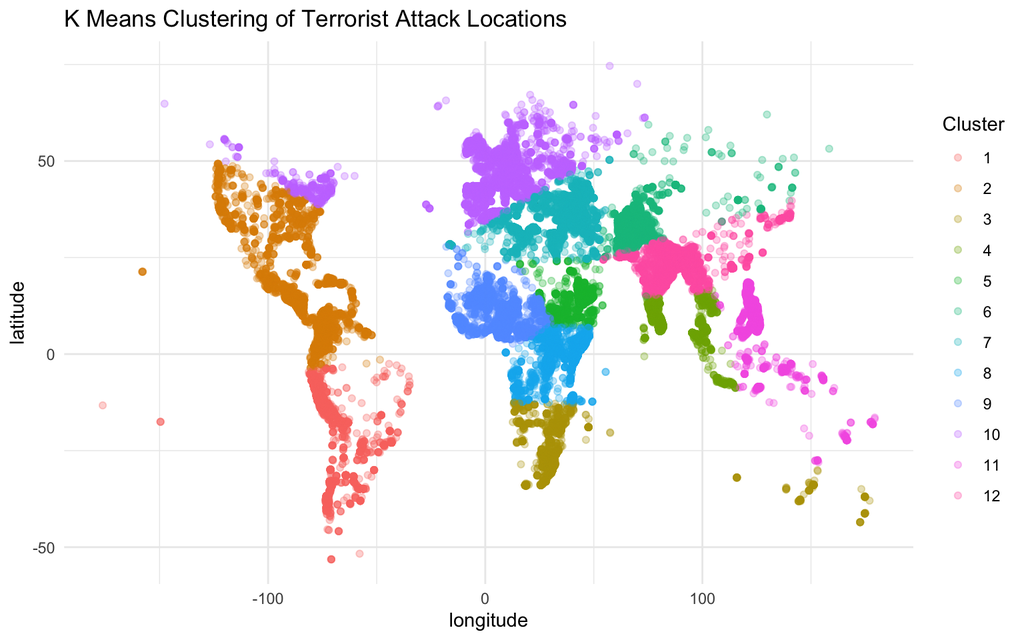

```r
cluster_plot <- cbind(unsup_data2, cluster = factor(kmeans_model$cluster))
ggplot(cluster_plot, aes(x = longitude, y = latitude, color = cluster)) +
  geom_point(alpha = 0.3) +
  theme_minimal() +
  ggtitle("K Means Clustering of Terrorist Attack Locations") +
  labs(color = "Cluster")
```

This code creates a visualization of the K means clustering results by combining the original latitude and longitude data with the assigned cluster labels. Each point on the scatter plot represents a terrorist attack location, and the color indicates which cluster it belongs to.

The plot shows how the K means algorithm partitions the data into distinct geographic groupings based on proximity. Rather than following predefined regional boundaries, the clusters are formed purely based on spatial distance, illustrating how the algorithm defines its own regions from the data.

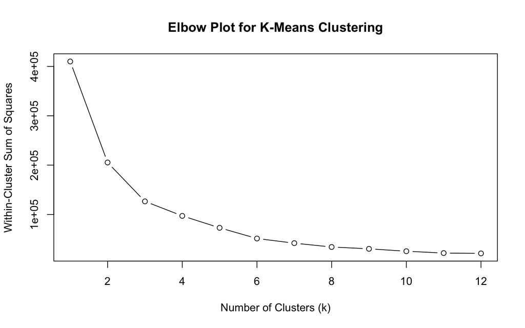

```r
wss <- numeric(12)
set.seed(7245)
for (i in 1:12) {
  wss[i] <- kmeans(unsup_scaled, centers = i, nstart = 25)$tot.withinss
}
plot(1:12, wss, type = "b",
     xlab = "Number of Clusters (k)",
     ylab = "Within-Cluster Sum of Squares",
     main = "Elbow Plot for K-Means Clustering")
```

This code calculates and visualizes the within-cluster sum of squares (WSS) for different values of k to help determine an appropriate number of clusters for the K means algorithm. The model is run multiple times with k ranging from 1 to 12, and the total within-cluster variation is recorded for each value.

The resulting plot, known as an elbow plot, shows how WSS decreases as the number of clusters increases. The goal is to identify a point where the rate of decrease slows down, indicating that adding more clusters provides diminishing improvements. This point helps guide the selection of an appropriate number of clusters for the analysis.

```r
clustered_data <- filteredGlobalTerrorism[!is.na(filteredGlobalTerrorism$latitude) &
                                          !is.na(filteredGlobalTerrorism$longitude), ]

clustered_data$cluster <- factor(kmeans_model$cluster)
table(clustered_data$cluster, clustered_data$region)
```

```
##
##          1     2     3     4     5     6     7     8     9    10    11    12
##   1      0     0  9881     0     0     0     0     0     0     0     0     4
##   2   2569  9386  9093     0     0     0     0     0     0     0     0     0
##   3      0     0     0     0     0     2     0     0     0     0  2929   134
##   4      0     0     0     0  4857  3348     0     0     0     0     0     0
##   5      0     0     0     0     0     1     0     0     0  6355   805     0
##   6      0     0     0   200     0 34944   266     0    40   119     0     0
##   7      0     0     0     0     1     0   298  1605  1972 48357     0     0
##   8      0     0     0     0     0     0     0     0     0     0  9785     0
##   9      0     0     0     0     0     1     0     1     0    16  9645     0
##   10  1272     0     0     0     5     1     1 15565  3287  2415     0     0
##   11     0     0     0     0  8318     0     0     0     0     0     0   181
##   12     0     0     0   639   783 15917     0     0     0    16     0     0
```

This code creates a dataset that includes only observations with valid latitude and longitude values and assigns each observation to its corresponding K means cluster. A contingency table is then generated to compare the cluster assignments with the predefined region variable.

The results show how observations from each region are distributed across the clusters. Some clusters are dominated by a single region, while others contain a mix of regions. This demonstrates that K means is grouping observations based on geographic proximity rather than predefined regional labels, creating its own data-driven groupings that may partially align with known regions but are not identical to them.

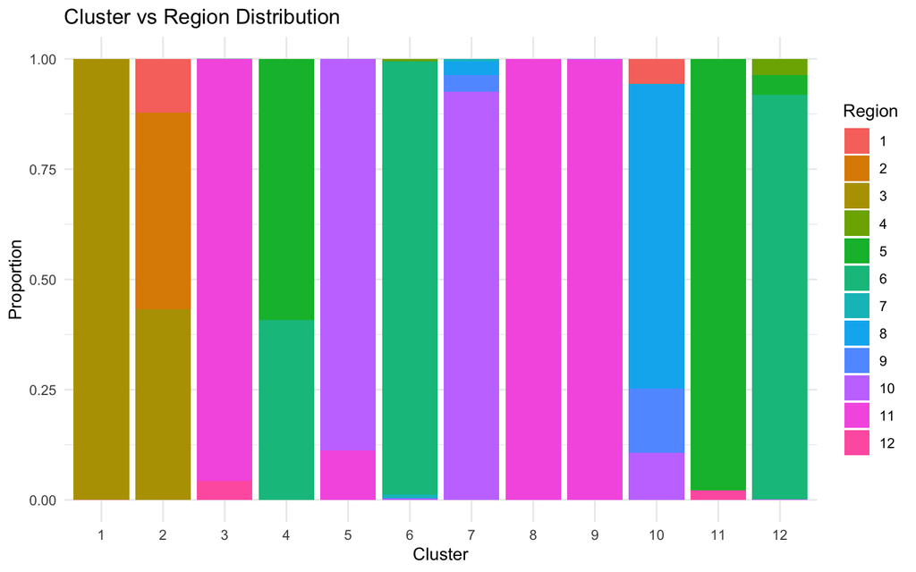

```r
ggplot(clustered_data, aes(x = cluster, fill = factor(region))) +
  geom_bar(position = "fill") +
  theme_minimal() +
  labs(title = "Cluster vs Region Distribution",
       x = "Cluster",
       y = "Proportion",
       fill = "Region")
```

The clustering results are compared to the predefined region variable to evaluate how the K means algorithm groups observations. The bar chart shows the proportion of each region within each cluster, highlighting how observations are distributed across clusters. Many clusters are dominated by one or a small number of regions, while others contain a mix, indicating that the algorithm is grouping points based on geographic proximity rather than predefined boundaries.

Overall, the results show that K means creates its own data driven geographic groupings that often resemble real world regions, but do not perfectly align with them. This suggests that terrorist activity is spatially concentrated, and that location alone is sufficient to form meaningful groupings in the data.

# Conclusion

This analysis demonstrates that both geographic factors and class imbalance play a major role in modeling terrorist activity. After filtering the dataset to focus on variables related to latitude and longitude, it becomes clear that location is one of the strongest underlying patterns in the data. The K means clustering results show that attacks are not randomly distributed, but instead form clear spatial groupings based solely on geographic proximity. While these clusters do not exactly match predefined regions, they highlight how the algorithm creates its own data-driven geographic structure, reinforcing the importance of spatial variables in understanding terrorist activity.

From the supervised modeling results, class imbalance in the success variable was the most significant challenge. The logistic regression model performed poorly, predicting only the majority class and failing to identify any unsuccessful attacks. Although the model achieved high accuracy, this was misleading because it simply reflected the underlying class distribution.

The Random Forest model showed improvement by correctly predicting some instances of the minority class, but performance remained limited with low sensitivity. The most effective model was the balanced Random Forest, which used up-sampling to address class imbalance. This approach significantly improved the model’s ability to detect unsuccessful attacks, increasing sensitivity and balanced accuracy while maintaining reasonable overall performance. Although accuracy decreased, this reflected a more meaningful model that no longer relied on majority class predictions.

Overall, the results show that handling class imbalance is more important than model complexity for this dataset. The balanced Random Forest model provided the most reliable performance, while the clustering analysis confirmed that geographic location is a key factor in understanding patterns of terrorist activity. Future work could focus on improving model performance through additional feature engineering, more advanced resampling techniques, or further tuning of ensemble models.

# Discussion

Overall, this project took more time than expected, especially when working with large datasets and computationally expensive models like Random Forest and XGBoost. One of the biggest challenges was dealing with class imbalance, which was not initially expected to have such a strong impact on model performance. The logistic regression results were especially surprising because the model appeared to perform well based on accuracy but completely failed when looking at other metrics.

Another challenge was the runtime of the models. Training models like Random Forest required significant time, which led to saving models and reloading them instead of retraining. This helped with efficiency but also required additional planning.

There were also some parts of the analysis that required rethinking, particularly the interpretation of K means clustering. Initially, the clusters were viewed as matching real-world regions, but it became clear that the algorithm is actually creating its own groupings based on distance rather than predefined boundaries.

If this project were to be done again, better time management and earlier consideration of class imbalance would improve the overall workflow. Additionally, more time could be spent tuning models like XGBoost, which may perform better with more careful parameter adjustments. Overall, this project provided a better understanding of both machine learning models and the challenges of working with real-world data.

# References

START (National Consortium for the Study of Terrorism and Responses to Terrorism). (2022). Global Terrorism Database 1970 - 2020 [data file]. https://www.start.umd.edu/gtd